# cs455-TP analysis

Team 16: Zach Walsh, Erik West, Trevor Isaacson

4/24/2022

## Data Preview

```
##   State Week Pollution Deaths Powerplants TransmissionLines
## 1    AL    1  6.428571   1580          55          26070620
## 2    AL    2  7.571429   1626          55          26070620
## 3    AL   11  8.714286   1554          55          26070620
## 4    AL   12  8.428571   1570          55          26070620
## 5    AL   13  6.571429   1532          55          26070620
## 6    AL   14  6.857143   1594          55          26070620
```

Goal is to see if powerplants and transmission lines led to increased pollution in a state.  
If there is increased pollution, does it lead to more deaths in the state?

## Variable Analysis

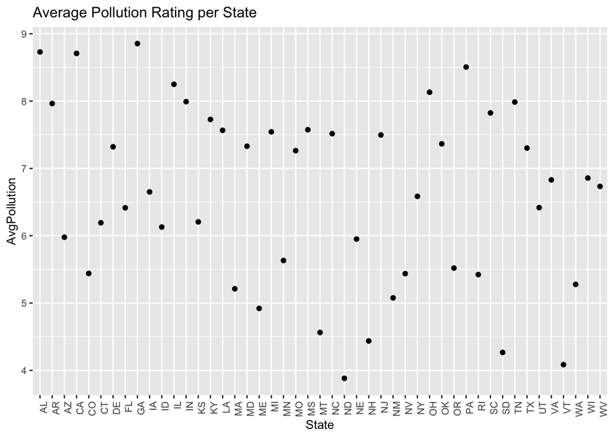

```r
final %>%
  group_by(State) %>%
  summarise(AvgPollution = sum(Pollution) / n()) %>%
  arrange(State) %>%
  ggplot() +
    geom_point(aes(x = State, y = AvgPollution)) +
    theme(text = element_text(size=10), axis.text.x = element_text(angle=90, hjust=1)) +
    ggtitle("Average Pollution Rating per State")
```

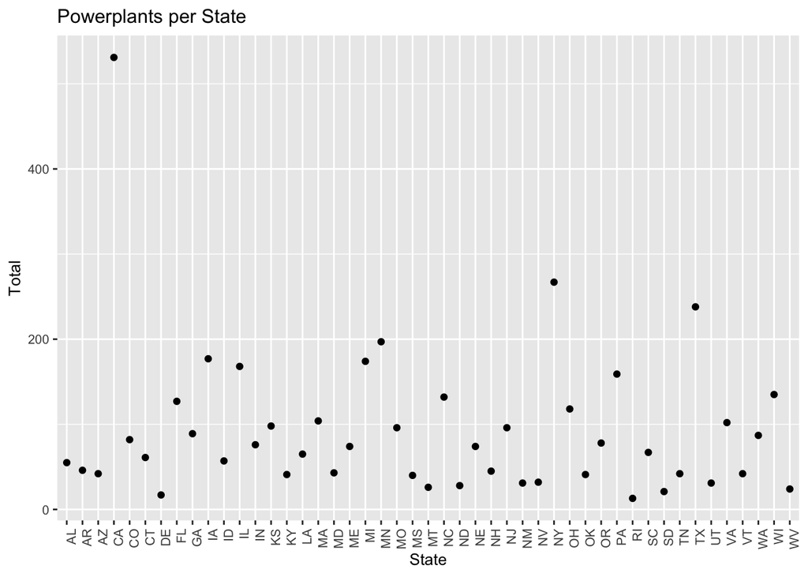

```r
final %>%
  group_by(State) %>%
  summarise(Total = sum(Powerplants) / n()) %>%
  arrange(State) %>%
  ggplot() +
    geom_point(aes(x = State, y = Total)) +
    theme(text = element_text(size=10), axis.text.x = element_text(angle=90, hjust=1)) +
    ggtitle("Powerplants per State")
```

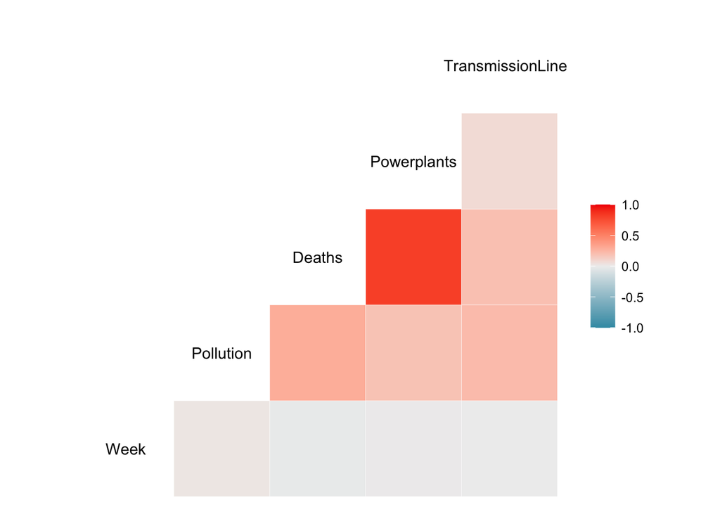

```r
ggcorr(final)
```

```r
summary(final)
```

```
##      State           Week         Pollution          Deaths
##  AL     :  52   Min.   : 1.00   Min.   : 1.286   Min.   :  46
##  AR     :  52   1st Qu.:13.50   1st Qu.: 4.857   1st Qu.: 482
##  AZ     :  52   Median :26.00   Median : 6.429   Median :1302
##  CA     :  52   Mean   :26.42   Mean   : 6.617   Mean   :1699
##  CO     :  52   3rd Qu.:39.00   3rd Qu.: 8.143   3rd Qu.:2075
##  CT     :  52   Max.   :52.00   Max.   :32.000   Max.   :9362
##  (Other):2103
##   Powerplants     TransmissionLines
##  Min.   : 13.00   Min.   :  433881
##  1st Qu.: 42.00   1st Qu.: 5316420
##  Median : 74.00   Median :14687587
##  Mean   : 94.22   Mean   :14891143
##  3rd Qu.:118.00   3rd Qu.:23169822
##  Max.   :531.00   Max.   :30491637
##
```

## Split into Training / Testing:

```r
trn = sample(seq_len(nrow(final)), nrow(final)*0.75)
training = final[trn, ]
testing = final[-trn, ]
```

## Train and Test Various Regression and ML models to determine correlation of pollution with other variables

Multiple Linear Regression to determine if pollution is caused by powerplants and electrical lines

```r
linreg_PT = lm(Pollution ~ Powerplants + TransmissionLines, data = training)
summary(linreg_PT)
```

```
##
## Call:
## lm(formula = Pollution ~ Powerplants + TransmissionLines, data = training)
##
## Residuals:
##     Min      1Q  Median      3Q     Max
## -5.2560 -1.6677 -0.3058  1.3249 26.4649
##
## Coefficients:
##                    Estimate Std. Error t value Pr(>|t|)
## (Intercept)       5.295e+00  1.241e-01  42.685  < 2e-16 ***
## Powerplants       4.673e-03  6.990e-04   6.685 3.06e-11 ***
## TransmissionLines 5.815e-08  6.350e-09   9.157  < 2e-16 ***
## ---
## Signif. codes:  0 '***' 0.001 '**' 0.01 '*' 0.05 '.' 0.1 ' ' 1
##
## Residual standard error: 2.485 on 1808 degrees of freedom
## Multiple R-squared:  0.07292,    Adjusted R-squared:  0.07189
## F-statistic:  71.1 on 2 and 1808 DF,  p-value: < 2.2e-16
```

```r
linreg_PT_predict = predict(linreg_PT, newdata = testing, type = "response")
RMSE_linreg_PT = sqrt(mean((testing$Pollution - linreg_PT_predict)^2))
print(paste("RMSE of linreg_PT on Testing Set: ", round(RMSE_linreg_PT, 4)))
```

```
## [1] "RMSE of linreg_PT on Testing Set:  2.1991"
```

Multiple Linear Regression to determine if pollution is caused by powerplants, electrical lines and state

```r
linreg_PTS = lm(Pollution ~ Powerplants + TransmissionLines + State, data = training)
summary(linreg_PTS)
```

```
##
## Call:
## lm(formula = Pollution ~ Powerplants + TransmissionLines + State,
##     data = training)
##
## Residuals:
##     Min      1Q  Median      3Q     Max
## -5.5436 -1.4211 -0.2895  1.0169 25.2481
##
## Coefficients: (2 not defined because of singularities)
##                     Estimate Std. Error t value Pr(>|t|)
## (Intercept)        4.901e+00  1.148e+00   4.269 2.07e-05 ***
## Powerplants       -1.311e-03  6.018e-03  -0.218 0.827518
## TransmissionLines  1.532e-07  4.172e-08   3.671 0.000249 ***
## StateAR            8.824e-01  5.408e-01   1.632 0.102930
## StateAZ            1.104e+00  1.001e+00   1.103 0.270071
## StateCA            4.110e+00  2.463e+00   1.669 0.095358 .
## StateCO           -2.730e+00  4.536e-01  -6.020 2.11e-09 ***
## StateCT            8.172e-01  9.089e-01   0.899 0.368696
## StateDE            2.164e+00  1.059e+00   2.043 0.041199 *
## StateFL           -1.960e+00  5.830e-01  -3.361 0.000793 ***
## StateGA           -2.385e-01  6.163e-01  -0.387 0.698829
## StateIA            3.677e-01  6.441e-01   0.571 0.568179
## StateID           -1.020e+00  5.087e-01  -2.005 0.045156 *
## StateIL           -1.092e-01  7.590e-01  -0.144 0.885569
## StateIN           -8.828e-01  5.033e-01  -1.754 0.079638 .
## StateKS           -1.503e+00  4.929e-01  -3.049 0.002331 **
## StateKY           -8.265e-01  4.815e-01  -1.717 0.086229 .
## StateLA            1.359e-01  4.621e-01   0.294 0.768656
## StateMA           -1.141e-01  7.094e-01  -0.161 0.872206
## StateMD            7.750e-01  7.208e-01   1.075 0.282378
## StateME           -7.623e-01  7.417e-01  -1.028 0.304171
## StateMI            2.428e-01  6.559e-01   0.370 0.711347
## StateMN           -2.534e+00  8.898e-01  -2.848 0.004455 **
## StateMO           -1.727e+00  5.962e-01  -2.897 0.003812 **
## StateMS           -5.135e-02  5.176e-01  -0.099 0.920983
## StateMT           -2.155e+00  7.304e-01  -2.950 0.003216 **
## StateNC           -1.790e+00  8.066e-01  -2.220 0.026572 *
## StateND           -2.134e+00  7.833e-01  -2.725 0.006497 **
## StateNE           -9.429e-01  4.734e-01  -1.992 0.046524 *
```

[output cut: 11 more lines]

```
## StateSD           -2.541e+00  6.693e-01  -3.796 0.000152 ***
## StateTN           -6.025e-01  4.955e-01  -1.216 0.224144
## StateTX            1.084e+00  9.152e-01   1.185 0.236350
## StateUT            1.642e+00  1.011e+00   1.625 0.104418
## StateVA           -1.911e+00  5.429e-01  -3.520 0.000443 ***
## StateVT           -3.984e+00  4.641e-01  -8.585  < 2e-16 ***
## StateWA           -1.017e+00  5.345e-01  -1.903 0.057155 .
## StateWI                   NA         NA      NA       NA
## StateWV                   NA         NA      NA       NA
## ---
## Signif. codes:  0 '***' 0.001 '**' 0.01 '*' 0.05 '.' 0.1 ' ' 1
##
## Residual standard error: 2.226 on 1764 degrees of freedom
## Multiple R-squared:  0.2744, Adjusted R-squared:  0.2555
## F-statistic:  14.5 on 46 and 1764 DF,  p-value: < 2.2e-16
```

```r
linreg_PTS_predict = predict(linreg_PTS, newdata = testing, type = "response")
RMSE_linreg_PTS = rmse(testing$Pollution, linreg_PTS_predict)
print(paste("RMSE of linreg_PTS on Testing Set: ", round(RMSE_linreg_PTS, 4)))
```

```
## [1] "RMSE of linreg_PTS on Testing Set:  1.9474"
```

Multiple Linear Regression to determine if pollution is caused by powerplants, electrical lines, state, week

```r
linreg_PTSW = lm(Pollution ~ Powerplants + TransmissionLines + State + Week, data = training)
summary(linreg_PTSW)
```

```
##
## Call:
## lm(formula = Pollution ~ Powerplants + TransmissionLines + State +
##     Week, data = training)
##
## Residuals:
##     Min      1Q  Median      3Q     Max
## -5.5738 -1.4188 -0.2936  1.0153 25.3551
##
## Coefficients: (2 not defined because of singularities)
##                     Estimate Std. Error t value Pr(>|t|)
## (Intercept)        4.839e+00  1.148e+00   4.215 2.63e-05 ***
## Powerplants       -1.592e-03  6.019e-03  -0.264 0.791479
## TransmissionLines  1.507e-07  4.174e-08   3.612 0.000313 ***
## StateAR            8.495e-01  5.410e-01   1.570 0.116555
## StateAZ            1.037e+00  1.002e+00   1.035 0.300591
## StateCA            4.180e+00  2.462e+00   1.698 0.089751 .
## StateCO           -2.735e+00  4.534e-01  -6.032 1.97e-09 ***
## StateCT            7.578e-01  9.094e-01   0.833 0.404803
## StateDE            2.099e+00  1.060e+00   1.980 0.047842 *
## StateFL           -1.945e+00  5.829e-01  -3.337 0.000863 ***
## StateGA           -2.289e-01  6.161e-01  -0.371 0.710310
## StateIA            3.722e-01  6.439e-01   0.578 0.563285
## StateID           -1.046e+00  5.089e-01  -2.056 0.039884 *
## StateIL           -8.578e-02  7.589e-01  -0.113 0.910022
## StateIN           -8.674e-01  5.033e-01  -1.724 0.084969 .
## StateKS           -1.517e+00  4.928e-01  -3.078 0.002115 **
## StateKY           -8.310e-01  4.813e-01  -1.727 0.084416 .
## StateLA            1.190e-01  4.621e-01   0.258 0.796820
## StateMA           -1.579e-01  7.098e-01  -0.222 0.824018
## StateMD            7.337e-01  7.210e-01   1.018 0.309015
## StateME           -8.101e-01  7.421e-01  -1.092 0.275138
## StateMI            2.553e-01  6.557e-01   0.389 0.697098
## StateMN           -2.492e+00  8.899e-01  -2.800 0.005164 **
## StateMO           -1.710e+00  5.961e-01  -2.869 0.004167 **
## StateMS           -8.475e-02  5.179e-01  -0.164 0.870027
## StateMT           -2.194e+00  7.306e-01  -3.003 0.002709 **
## StateNC           -1.760e+00  8.066e-01  -2.182 0.029271 *
## StateND           -2.187e+00  7.838e-01  -2.790 0.005323 **
## StateNE           -9.690e-01  4.735e-01  -2.046 0.040867 *
```

[output cut: 12 more lines]

```
## StateTN           -6.094e-01  4.953e-01  -1.230 0.218759
## StateTX            1.100e+00  9.149e-01   1.203 0.229217
## StateUT            1.578e+00  1.012e+00   1.560 0.118956
## StateVA           -1.896e+00  5.428e-01  -3.492 0.000491 ***
## StateVT           -4.003e+00  4.641e-01  -8.625  < 2e-16 ***
## StateWA           -1.033e+00  5.344e-01  -1.933 0.053410 .
## StateWI                   NA         NA      NA       NA
## StateWV                   NA         NA      NA       NA
## Week               5.239e-03  3.498e-03   1.498 0.134339
## ---
## Signif. codes:  0 '***' 0.001 '**' 0.01 '*' 0.05 '.' 0.1 ' ' 1
##
## Residual standard error: 2.225 on 1763 degrees of freedom
## Multiple R-squared:  0.2753, Adjusted R-squared:  0.256
## F-statistic: 14.25 on 47 and 1763 DF,  p-value: < 2.2e-16
```

```r
linreg_PTSW_predict = predict(linreg_PTSW, newdata = testing, type = "response")
RMSE_linreg_PTSW = rmse(testing$Pollution, linreg_PTSW_predict)
print(paste("RMSE of linreg_PTSW on Testing Set: ", round(RMSE_linreg_PTSW, 4)))
```

```
## [1] "RMSE of linreg_PTSW on Testing Set:  1.9487"
```

Fit Pollution Tree with Powerplants, Electrical Lines and Week

```r
# fit regression tree
tree_PTW = tree(Pollution ~ Powerplants + TransmissionLines + Week, data = training)

tree_PTW_predict = predict(tree_PTW, newdata = testing)
RMSE_tree_PTW = rmse(testing$Pollution, tree_PTW_predict)
print(paste("Test RMSE of Tree_PTS: ", round(RMSE_tree_PTW, 4)))
```

```
## [1] "Test RMSE of Tree_PTS:  2.0997"
```

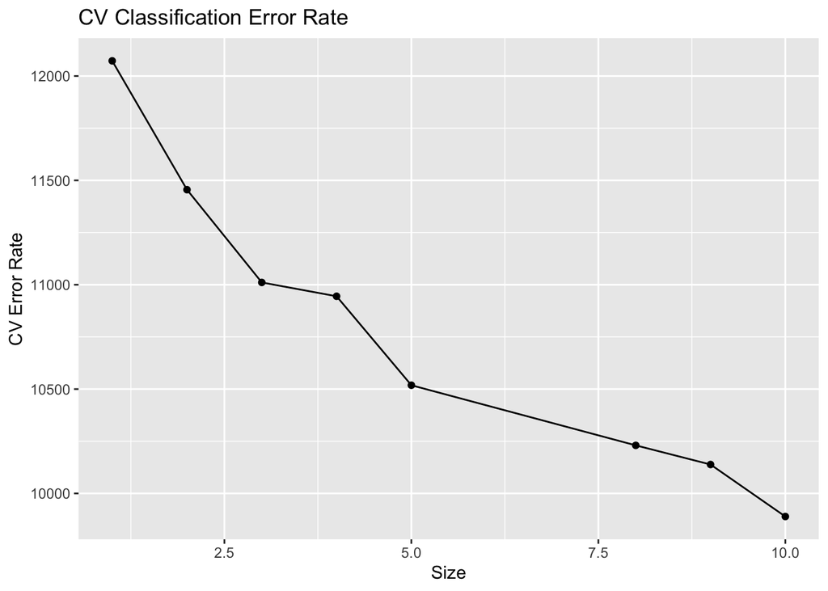

```r
# cross validation
tree_PTW_cv = cv.tree(tree_PTW)
ggplot() +
  geom_point(aes(x = tree_PTW_cv$size, y = tree_PTW_cv$dev)) +
  geom_line(aes(x = tree_PTW_cv$size, y = tree_PTW_cv$dev)) +
  ylab("CV Error Rate") + xlab("Size") + ggtitle("CV Classification Error Rate")
```

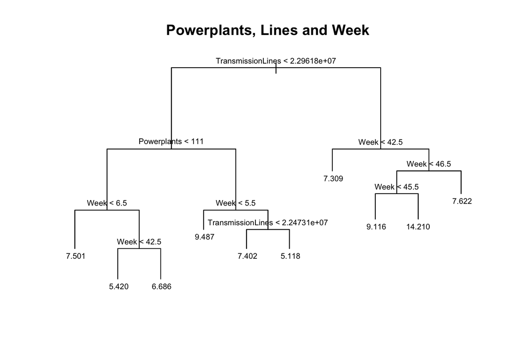

```r
# pruned by CV
prune_tree_PTW <- prune.tree(tree_PTW, best = 7)
plot(tree_PTW)
text(tree_PTW, cex = 0.65, digits = 4, pretty = 0)
title("Powerplants, Lines and Week")
```

Random Forest for Pollution on All Variables

```r
bag_pollution <- randomForest(Pollution ~ State + Week + TransmissionLines + Powerplants, data = training, importance = TRUE)

bag_pollution_predict = predict(bag_pollution, testing, type = "response")
bag_pollution_RMSE = rmse(testing$Pollution, bag_pollution_predict)
print(paste("Test RMSE of bag_pollution: ", round(bag_pollution_RMSE, 4)))
```

```
## [1] "Test RMSE of bag_pollution:  1.7257"
```

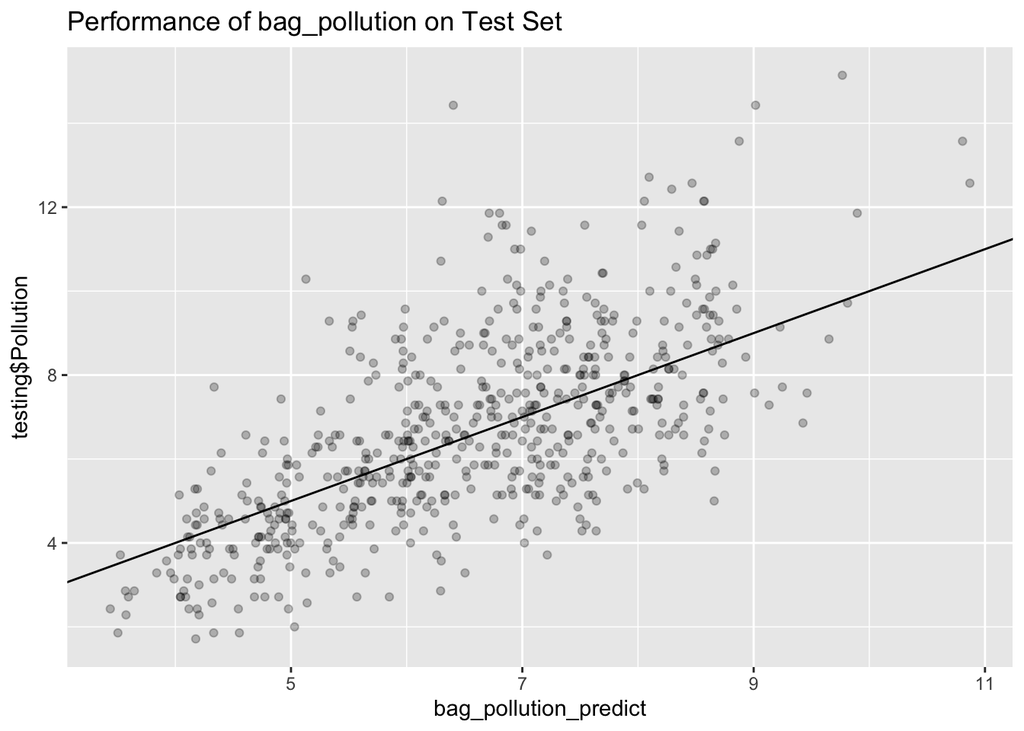

```r
ggplot() +
  geom_point(aes(x = bag_pollution_predict, y = testing$Pollution), alpha = 0.25) +
  geom_abline(slope = 1, intercept = 0) +
  ggtitle("Performance of bag_pollution on Test Set")
```

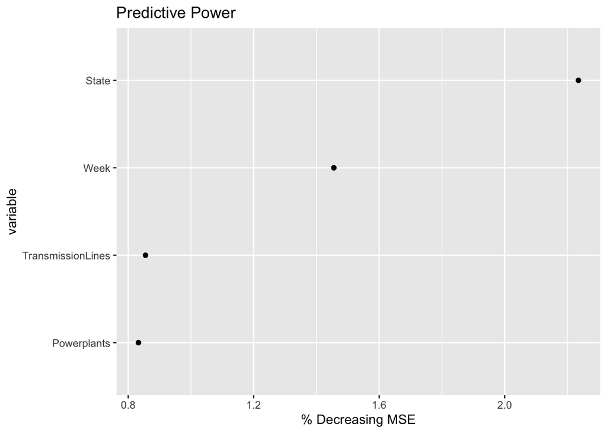

```r
data.frame(bag_pollution$importance) %>%
  mutate(variable = rownames(bag_pollution$importance)) %>%
  mutate(variable = factor(variable, levels = variable[order(X.IncMSE)])) %>%
  ggplot() + ggtitle("Predictive Power") + xlab("% Decreasing MSE") +
  geom_point(aes(X.IncMSE, variable))
```

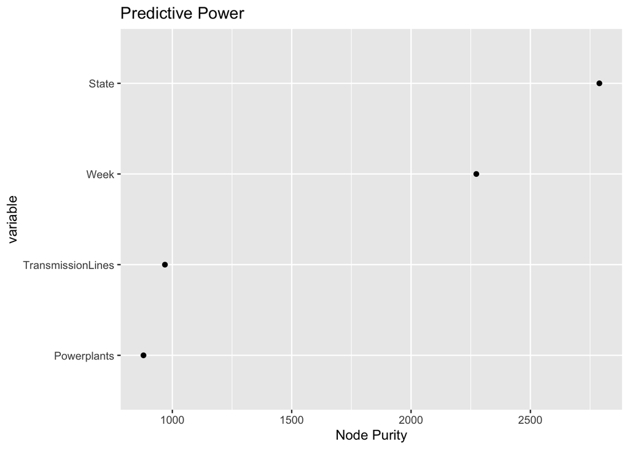

```r
data.frame(bag_pollution$importance) %>%
  mutate(variable = rownames(bag_pollution$importance)) %>%
  mutate(variable = factor(variable, levels = variable[order(IncNodePurity)])) %>%
  ggplot() + ggtitle("Predictive Power") + xlab("Node Purity") +
  geom_point(aes(IncNodePurity, variable))
```

Boosting for Pollution with All Variables

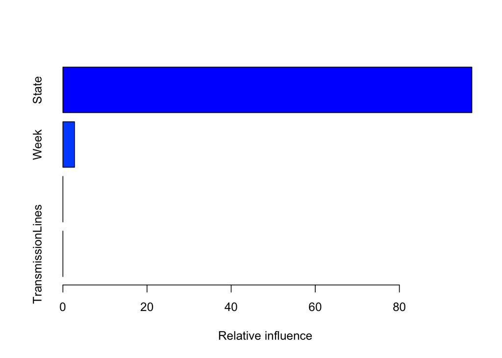

```
##                                 var   rel.inf
## State                         State 97.229453
## Week                           Week  2.770547
## Powerplants             Powerplants  0.000000
## TransmissionLines TransmissionLines  0.000000
```

```r
lambdas = seq(0, 5, length.out = 100)
trainErrors = rep(NA, length(lambdas))
testErrors = rep(NA, length(lambdas))
for(i in 1:length(lambdas)){
  boost = gbm(Pollution ~ State + Week + Powerplants + TransmissionLines, data = training, n.trees = 100, shrinkage = lambdas[i], distribution = "gaussian")
  trainPred = predict(boost, training, n.trees = 100)
  testPred = predict(boost, testing, n.trees = 100)
  trainErrors[i] = mean((training$Pollution - trainPred)^2)
  testErrors[i] = mean((testing$Pollution - testPred)^2)
}

boostedPollution = gbm(Pollution ~ State + Week + Powerplants + TransmissionLines, data = training, n.trees = 500, shrinkage = lambdas[which.min(testErrors)], distribution = "gaussian")
summary(boostedPollution)
```

```r
boostedPollution_pred = predict(boostedPollution, testing)
```

```
## Using 500 trees...
```

```r
boostedPollution_RMSE = round(sqrt(mean((testing$Pollution - boostedPollution_pred)^2)), 4)
print(paste("Testing MSE for Boosted Pollution Model:", boostedPollution_RMSE))
```

```
## [1] "Testing MSE for Boosted Pollution Model: 1.7827"
```

## Train and Test Various Regression and ML models to determine correlation of state deaths with other variables

Multiple Linear Regression for Death with All Variables

```r
linreg_DA = lm(Deaths ~ ., data = training)
summary(linreg_DA)
```

```
##
## Call:
## lm(formula = Deaths ~ ., data = training)
##
## Residuals:
##     Min      1Q  Median      3Q     Max
## -822.39  -65.93   -6.33   58.84 1496.46
##
## Coefficients: (2 not defined because of singularities)
##                     Estimate Std. Error t value Pr(>|t|)
## (Intercept)        1507.5237    30.3212  49.719  < 2e-16 ***
## StateAR            -618.6374    35.8463 -17.258  < 2e-16 ***
## StateAZ              66.5618    36.1368   1.842 0.065652 .
## StateCA            6368.2985    37.5941 169.396  < 2e-16 ***
## StateCO            -479.4950    36.7104 -13.062  < 2e-16 ***
## StateCT            -616.8760    38.2352 -16.134  < 2e-16 ***
## StateDE           -1327.0574    35.4987 -37.383  < 2e-16 ***
## StateFL            4395.2547    37.0109 118.756  < 2e-16 ***
## StateGA             888.2914    35.6081  24.946  < 2e-16 ***
## StateIA            -686.1281    36.4625 -18.817  < 2e-16 ***
## StateID           -1188.1926    36.8078 -32.281  < 2e-16 ***
## StateIL            1601.0922    36.7795  43.532  < 2e-16 ***
## StateIN             381.8544    35.6418  10.714  < 2e-16 ***
## StateKS            -791.6385    39.9557 -19.813  < 2e-16 ***
## StateKY            -115.8827    35.6520  -3.250 0.001174 **
## StateLA            -206.8198    36.5785  -5.654 1.82e-08 ***
## StateMA             195.4961    36.1496   5.408 7.25e-08 ***
## StateMD             -96.4393    36.4101  -2.649 0.008152 **
## StateME           -1153.7020    36.9288 -31.241  < 2e-16 ***
## StateMI            1351.9083    35.4720  38.112  < 2e-16 ***
## StateMN            -299.1541    36.6923  -8.153 6.66e-16 ***
## StateMO             327.3665    35.1113   9.324  < 2e-16 ***
## StateMS            -581.8921    37.3639 -15.574  < 2e-16 ***
## StateMT           -1284.3449    37.0802 -34.637  < 2e-16 ***
## StateNC            1180.7681    36.0974  32.711  < 2e-16 ***
## StateND           -1370.8169    37.4214 -36.632  < 2e-16 ***
## StateNE           -1089.5087    35.1972 -30.954  < 2e-16 ***
## StateNH           -1222.1778    37.0147 -33.019  < 2e-16 ***
## StateNJ             691.9321    36.1206  19.156  < 2e-16 ***
## StateNM           -1098.6100    37.0743 -29.633  < 2e-16 ***
```

[output cut: 12 more lines]

```
## StateVA             435.2240    36.2178  12.017  < 2e-16 ***
## StateVT           -1380.6635    36.1764 -38.165  < 2e-16 ***
## StateWA              60.8294    37.4752   1.623 0.104728
## StateWI             -42.7769    36.4392  -1.174 0.240583
## StateWV            -962.5562    50.2091 -19.171  < 2e-16 ***
## Week                 -2.0165     0.2535  -7.954 3.19e-15 ***
## Pollution             8.9461     1.7251   5.186 2.40e-07 ***
## Powerplants               NA         NA      NA       NA
## TransmissionLines         NA         NA      NA       NA
## ---
## Signif. codes:  0 '***' 0.001 '**' 0.01 '*' 0.05 '.' 0.1 ' ' 1
##
## Residual standard error: 161.2 on 1762 degrees of freedom
## Multiple R-squared:  0.9904, Adjusted R-squared:  0.9901
## F-statistic:  3781 on 48 and 1762 DF,  p-value: < 2.2e-16
```

```r
linreg_DA_predict = predict(linreg_DA, newdata = testing, type = "response")
RMSE_linreg_DA = sqrt(mean((testing$Deaths - linreg_DA_predict)^2))
print(paste("RMSE of linreg_PT Testing Set: ", round(RMSE_linreg_DA, 4)))
```

```
## [1] "RMSE of linreg_PT Testing Set:  163.9117"
```

Random Forest for Deaths on All Variables

```r
bag_deaths <- randomForest(Deaths ~ ., data = training, importance = TRUE)

bag_deaths_predict = predict(bag_deaths, testing, type = "response")
bag_deaths_RMSE = rmse(testing$Deaths, bag_deaths_predict)
print(paste("Test RMSE of bag_pollution: ", round(bag_deaths_RMSE, 4)))
```

```
## [1] "Test RMSE of bag_pollution:  186.7234"
```

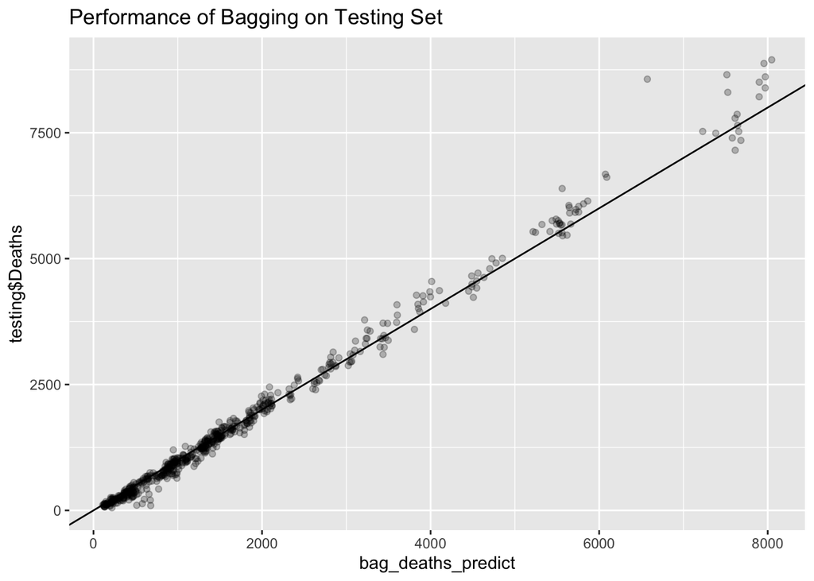

```r
ggplot() +
  geom_point(aes(x = bag_deaths_predict, y = testing$Deaths), alpha = 0.25) +
  geom_abline(slope = 1, intercept = 0) +
  ggtitle("Performance of Bagging on Testing Set")
```

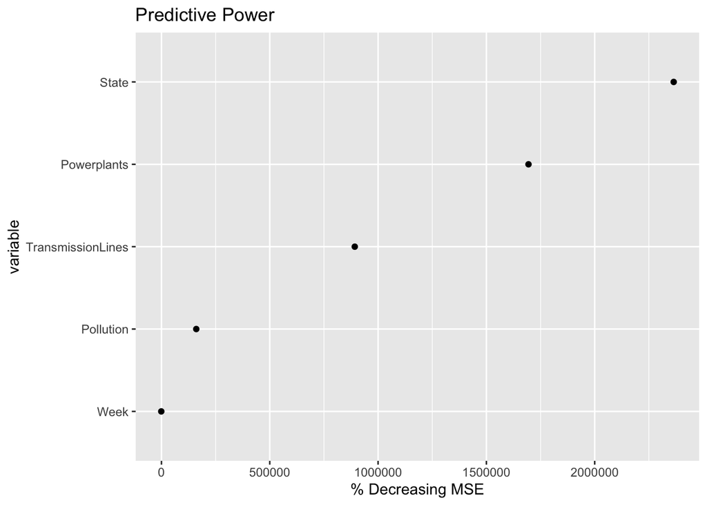

```r
data.frame(bag_deaths$importance) %>%
  mutate(variable = rownames(bag_deaths$importance)) %>%
  mutate(variable = factor(variable, levels = variable[order(X.IncMSE)])) %>%
  ggplot() + ggtitle("Predictive Power") + xlab("% Decreasing MSE") +
  geom_point(aes(X.IncMSE, variable))
```

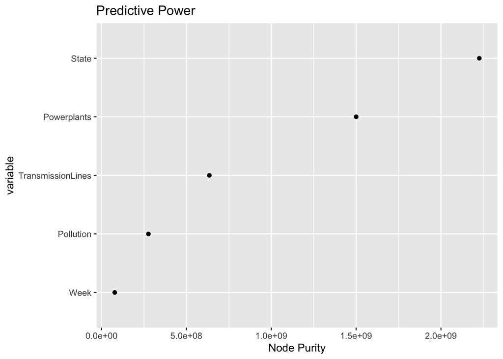

```r
data.frame(bag_deaths$importance) %>%
  mutate(variable = rownames(bag_deaths$importance)) %>%
  mutate(variable = factor(variable, levels = variable[order(IncNodePurity)])) %>%
  ggplot() + ggtitle("Predictive Power") + xlab("Node Purity") +
  geom_point(aes(IncNodePurity, variable))
```

Random Forest for Deaths on All Variables Except State

```r
bag_DES <- randomForest(Deaths ~ Week + TransmissionLines + Powerplants + Pollution, data = training, importance = TRUE)

bag_DES_predict = predict(bag_DES, testing, type = "response")
bag_DES_RMSE = rmse(testing$Deaths, bag_DES_predict)
print(paste("Test RMSE of bag_deaths without states: ", round(bag_DES_RMSE, 4)))
```

```
## [1] "Test RMSE of bag_deaths without states:  345.8139"
```

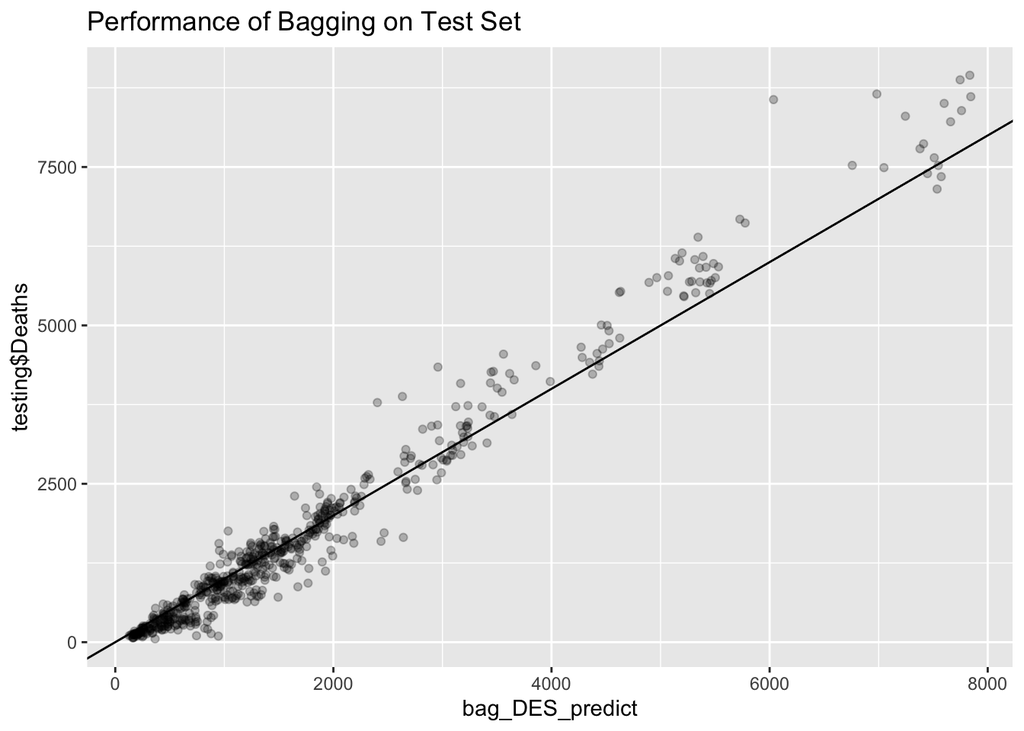

```r
ggplot() +
  geom_point(aes(x = bag_DES_predict, y = testing$Deaths), alpha = 0.25) +
  geom_abline(slope = 1, intercept = 0) +
  ggtitle("Performance of Bagging on Test Set")
```

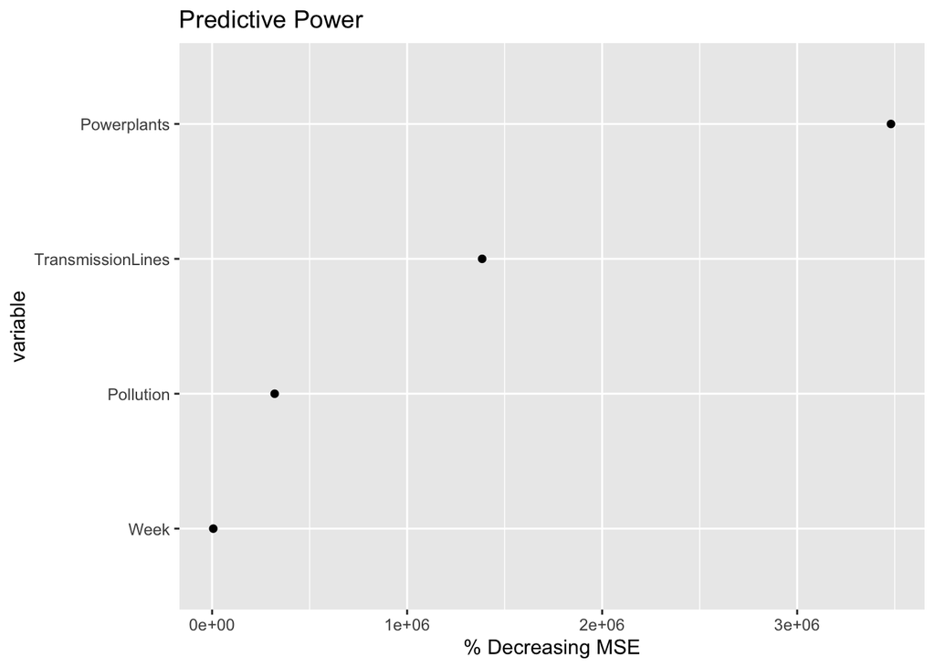

```r
data.frame(bag_DES$importance) %>%
  mutate(variable = rownames(bag_DES$importance)) %>%
  mutate(variable = factor(variable, levels = variable[order(X.IncMSE)])) %>%
  ggplot() + ggtitle("Predictive Power") + xlab("% Decreasing MSE") +
  geom_point(aes(X.IncMSE, variable))
```

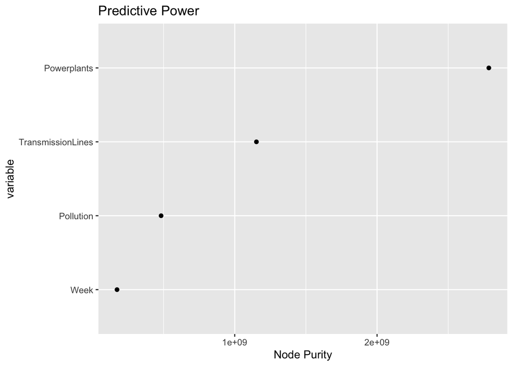

```r
data.frame(bag_DES$importance) %>%
  mutate(variable = rownames(bag_DES$importance)) %>%
  mutate(variable = factor(variable, levels = variable[order(IncNodePurity)])) %>%
  ggplot() + ggtitle("Predictive Power") + xlab("Node Purity") +
  geom_point(aes(IncNodePurity, variable))
```

Boosting for Death with All Variables

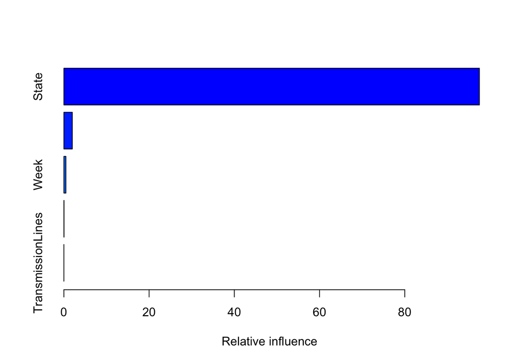

```
##                                 var     rel.inf
## State                         State 97.52160739
## Powerplants             Powerplants  1.97682970
## Week                           Week  0.47127881
## Pollution                 Pollution  0.03028409
## TransmissionLines TransmissionLines  0.00000000
```

```r
lambdas = seq(0, 5, length.out = 100)
trainErrors = rep(NA, length(lambdas))
testErrors = rep(NA, length(lambdas))
for(i in 1:length(lambdas)){
  boost = gbm(Deaths ~ ., data = training, n.trees = 100, shrinkage = lambdas[i], distribution = "gaussian")
  trainPred = predict(boost, training, n.trees = 100)
  testPred = predict(boost, testing, n.trees = 100)
  trainErrors[i] = mean((training$Deaths - trainPred)^2)
  testErrors[i] = mean((testing$Deaths - testPred)^2)
}

boosted = gbm(Deaths ~ ., data = training, n.trees = 500, shrinkage = lambdas[which.min(testErrors)], distribution = "gaussian")
summary(boosted)
```

```r
boosted_pred = predict(boosted, testing)
```

```
## Using 500 trees...
```

```r
boosted_RMSE = round(sqrt(mean((testing$Deaths - boosted_pred)^2)), 4)
print(paste("Testing MSE for Boosted Model:", boosted_RMSE))
```

```
## [1] "Testing MSE for Boosted Model: 134.8334"
```

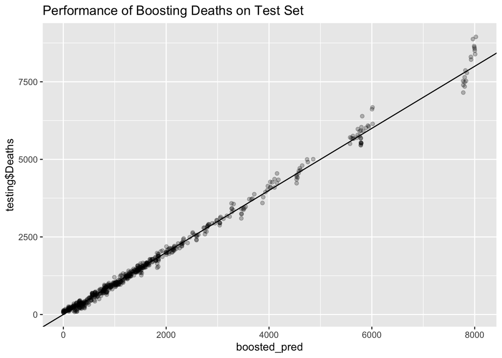

```r
ggplot() +
  geom_point(aes(x = boosted_pred, y = testing$Deaths), alpha = 0.25) +
  geom_abline(slope = 1, intercept = 0) +
  ggtitle("Performance of Boosting Deaths on Test Set")
```

## RMSE Pollution Table

```r
method = c("Linear Regression Pollution (PP + TL)", "Linear Regression Pollution (PP + TL + St)", "Linear Regression Pollution (All)", "Trees (No State)",
           "Bagging Pollution RMSE (All)", "Boosting Pollution RMSE (All)")
RMSEpollution = c(RMSE_linreg_PT, RMSE_linreg_PTS, RMSE_linreg_PTSW, RMSE_tree_PTW, bag_pollution_RMSE, boostedPollution_RMSE)
maxPollution = max(final$Pollution)
minPollution = min(final$Pollution)
normRMSEPollution = c(RMSE_linreg_PT/(maxPollution-minPollution), RMSE_linreg_PTS/(maxPollution-minPollution), RMSE_linreg_PTSW/(maxPollution-minPollution), RMSE_tree_PTW/(maxPollution-minPollution), bag_pollution_RMSE/(maxPollution-minPollution), boostedPollution_RMSE/(maxPollution-minPollution))

finalRMSEpollution = data.frame(Methods = method, RMSE = round(RMSEpollution,4), NormRMSE = round(normRMSEPollution, 4))
finalRMSEpollution
```

```
##                                      Methods   RMSE NormRMSE
## 1      Linear Regression Pollution (PP + TL) 2.1991   0.0716
## 2 Linear Regression Pollution (PP + TL + St) 1.9474   0.0634
## 3          Linear Regression Pollution (All) 1.9487   0.0634
## 4                           Trees (No State) 2.0997   0.0684
## 5               Bagging Pollution RMSE (All) 1.7257   0.0562
## 6              Boosting Pollution RMSE (All) 1.7827   0.0580
```

## RMSE Death Table

Normalizing RMSE scores gives us a better understanding of how “good” our model does at predicting Values are 0 to 1 Closer to 0 represents a better number

```r
method = c("Linear Regression Deaths (All)", "Bagging Deaths (All)", "Bagging Deaths (No States)", "Boosting Death (All)")
RMSEdeaths = c(RMSE_linreg_DA, bag_deaths_RMSE, bag_DES_RMSE, boosted_RMSE)
maxDeaths = max(final$Deaths)
minDeaths = min(final$Deaths)
normRMSEDeaths = c(RMSE_linreg_DA/(maxDeaths-minDeaths), bag_deaths_RMSE/(maxDeaths-minDeaths), bag_DES_RMSE/(maxDeaths-minDeaths), boosted_RMSE/(maxDeaths-minDeaths))

finalRMSEdeaths = data.frame(Methods = method, RMSE = round(RMSEdeaths, 4), NormRMSE = round(normRMSEDeaths,4))
finalRMSEdeaths
```

```
##                          Methods     RMSE NormRMSE
## 1 Linear Regression Deaths (All) 163.9117   0.0176
## 2           Bagging Deaths (All) 186.7234   0.0200
## 3     Bagging Deaths (No States) 345.8139   0.0371
## 4           Boosting Death (All) 134.8334   0.0145
```

## Final Model: Does higher pollution correlate to more deaths?

```r
lambdas = seq(0, 5, length.out = 100)
trainErrors = rep(NA, length(lambdas))
testErrors = rep(NA, length(lambdas))
for(i in 1:length(lambdas)){
  boost = gbm(Deaths ~ Pollution, data = training, n.trees = 100, shrinkage = lambdas[i], distribution = "gaussian")
  trainPred = predict(boost, training, n.trees = 100)
  testPred = predict(boost, testing, n.trees = 100)
  trainErrors[i] = mean((training$Deaths - trainPred)^2)
  testErrors[i] = mean((testing$Deaths - testPred)^2)
}

finalBoosted = gbm(Deaths ~ Pollution, data = training, n.trees = 500, shrinkage = lambdas[which.min(testErrors)], distribution = "gaussian")

finalBoosted_pred = predict(finalBoosted, testing)
finalBoosted_RMSE = round(sqrt(mean((testing$Deaths - finalBoosted_pred)^2)), 4)
print(paste("Testing MSE for Boosted Model on Test Set:", finalBoosted_RMSE))
```

```
## [1] "Testing MSE for Boosted Model on Test Set: 1704.3485"
```